# Automaty komórkowe - modelowanie epidemii

### Autor: Jacek Nitychoruk

## Model SIR epidemii

Zwany również modelem Kermacka-McKendricka. Populację dzielimy na trzy grupy:

- S - osoby podatne na infekcję (*susceptible*)
- I - osoby zainfekowane (*infected*) - przezaujące chorobę w wyniku kontaktu
- R - osoby, które nabyły odpowrność po przejściu choroby i nie zakażają (*resistant*)

gdzie:

- $\beta$ - współczynnik przenoszenia choroby,
- $N$ - liczba osób w populacji
- $\gamma$ - współczynnik powrotu do zdrowia - $\frac{1}{\gamma}$ to średni czas trwania choroby

### Wykresy zmian liczby osób w poszczególnych stanach

Wykresy matematycznego modelu wygenerowałem przy użyciu następującego programu:

```
318.58558888158603
```

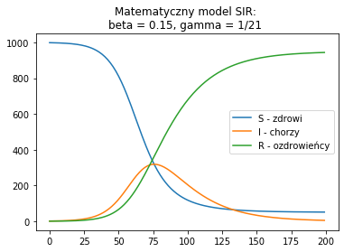

```python
from scipy.integrate import odeint
import matplotlib.pyplot as plt

population = 1000
I0 = 1
R0 = 0
S0 = population - I0 - R0
beta = 0.15
gamma =  1.0/21
time = range(200)

def der(y, time, population, beta, gamma):
    S, I, R = y
    dS = -beta * S * I / population
    dI = beta * S * I / population - gamma * I
    dR = gamma * I
    return dS, dI, dR

begin_state = (S0, I0, R0)
res = odeint(der, begin_state, time, args=(population, beta, gamma))
s = [el[0] for el in res]
i = [el[1] for el in res]
r = [el[2] for el in res]

plt.plot(s)
plt.plot(i)
plt.plot(r)
plt.title('Matematyczny model SIR: \nbeta = 0.15, gamma = 1/21 ')
plt.legend(['S - zdrowi', 'I - chorzy', 'R - ozdrowieńcy'])
print(max(i))
```

Przy populacji 1000 osób, średnim czasie trwania choroby - 21 dni (przyjmuję, że tyle trwa choroba Covid-19) oraz współczynniku $\beta=0.15$ w momencie szczytowym epidemii, zakażonych jest 319 osób.

#### Wykres dla $\beta=0.25$:

[output not shown]

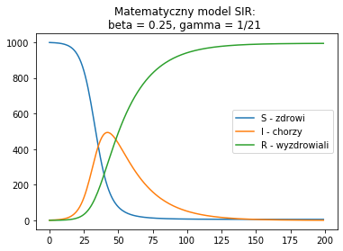

```python
beta = 0.25

res2 = odeint(der, begin_state, time, args=(population, beta, gamma))
s2 = [el[0] for el in res2]
i2 = [el[1] for el in res2]
r2 = [el[2] for el in res2]

plt.plot(s2)
plt.plot(i2)
plt.plot(r2)
plt.title('Matematyczny model SIR: \nbeta = 0.25, gamma = 1/21 ')
plt.legend(['S - zdrowi', 'I - chorzy', 'R - ozdrowieńcy'])
print(max(i2))
```

dla $\beta=0.25$ liczba zakażonych wzrosłą do ponad 49%, i niemal wszyscy w populacji (99.5%) przeszli chorobę.

#### Wykres dla $\beta=0.25$ i czasu trwania choroby 10 dni (np. grypa):

```
233.83200981918316
```

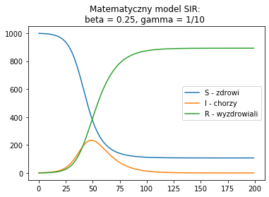

```python
beta = 0.25
gamma = 1.0/10

res3 = odeint(der, begin_state, time, args=(population, beta, gamma))
s3 = [el[0] for el in res3]
i3 = [el[1] for el in res3]
r3 = [el[2] for el in res3]

plt.plot(s3)
plt.plot(i3)
plt.plot(r3)
plt.title('Matematyczny model SIR: \nbeta = 0.25, gamma = 1/10 ')
plt.legend(['S - zdrowi', 'I - chorzy', 'R - ozdrowieńcy'])
print(max(i3))
```

## Doświadczenie przy użyciu automatu komórkowego

Przy użyciu poniższego programu skonsruowałem automat komórkowy, symulujący rozwój epidemii. Parametry, które można zmieniać, aby symulować przebieg epidemii, to:

- $x_{max}, y_{max}$ - rozmiary automatu komórkowego
- $c$ - prawdopodobieństwo wyzdrowienia - $\frac1c$ określa średni czas trwania choroby
- $\alpha$ - współczynnik przemieszczania się - określa jaka część populacji przemieści się w jednej turze (zamieni się miejscami z losowo wybraną inną komórką)
- $\beta$ - współczynnik zarażania - określa prawdopodobieństwo zarażenia przez komórkę w stanie zakażonym, komórki w pobliżu (również po przekątnej)
- $I_{start}$ - początkowa liczba komórek zakażonych

Legenda do animacji:

- kolor **zielony** - zdrowy (S)
- kolor **czerwony** - chory (I)
- kolor **beżowy** - wyzdrowiały (R)

Pierwszą symulację wykonałem dla automatu 10x10, dla średniego czasu choroby - 21 dni, przemieszczania się 1% populacji, współczynnika zarażania - 0.5 i dokładnie 1 osoby chorej na początku.

```python
import numpy as np
import seaborn as sns
from matplotlib import animation
from IPython.display import Image
import random
```

```python
x_max=10
y_max=10

c = 1.0/21
alpha = 0.01
beta = 0.5
start_i=1


stats = []
population = x_max*y_max
movements = int(population*alpha)

SUSCEPTIBLE = 2
INFECTED = 0
REMOVED = 1
```

```python
def init():
    global data
    global stats
    stats = []
    data=np.full((y_max, x_max), SUSCEPTIBLE)

    for i in range(start_i):
        while True:
            y = np.random.randint(low=0, high=y_max)
            x = np.random.randint(low=0, high=x_max)
            if data[y][x] == SUSCEPTIBLE: break
        data[y][x] = INFECTED
```

```python
def pick_random_neighbour(x, y):
    assert x < x_max and y < y_max and x >= 0 and y >= 0

    dirs = [(1, 0), (1, -1), (0, -1), (-1, -1), (-1, 0), (-1, 1), (0, 1), (1, 1)]
    while True:
        dir = np.random.randint(low=0, high=8)
        dir = dirs[dir]
        if x + dir[0] < x_max and  x + dir[0] >= 0 and y + dir[1] < y_max and y + dir[1] >=0:
            res_x = x + dir[0]
            res_y = y + dir[1]
            break
    return (res_x ,res_y)
```

```python
def count(data, state):
    res = 0
    for y in data:
        for el in y:
            if el == state:
                res+=1
    return res
```

```python
def make_movements(count):
    for it in range(count):
        x1 = np.random.randint(low=0, high=x_max)
        y1 = np.random.randint(low=0, high=y_max)
        x2 = np.random.randint(low=0, high=x_max)
        y2 = np.random.randint(low=0, high=y_max)
        data[y1][x1], data[y2][x2] = data[y2][x2], data[y1][x1] # Swaps random cells
```

```python
def animate(i):
    print(i, end=' ')
    global stats
    global data
    global c
    make_movements(movements)
    new_data = [row[:] for row in data]
    for x in range(x_max):
        for y in range(y_max):
            if data[y][x] == INFECTED:
                r = np.random.rand()
                if r < c:
                    new_data[y][x] = REMOVED
                else:
                    if np.random.rand() < beta:
                        n_x, n_y = pick_random_neighbour(x, y)
                        if data[n_y][n_x] == SUSCEPTIBLE:
                            new_data[n_y][n_x] = INFECTED

    stats.append([count(data, SUSCEPTIBLE), count(data, INFECTED), count(data, REMOVED)])
    data = new_data
    plt.imshow(new_data)
    plt.clim(0,2)
    plt.set_cmap('RdYlGn')
    plt.show
```

```
0 1 2 3 4 5 6 7 8 9 10 11 12 13 14 15 16 17 18 19 20 21 22 23 24 25 26 27 28 29 30 31 32 33 34 35 36 37 38 39 40 41 42 43 44 45 46 47 48 49 50 51 52 53 54 55 56 57 58 59 60 61 62 63 64 65 66 67 68 69
```

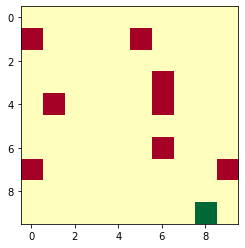

```python
def animate_heat_map():
    fig = plt.figure()
    anim = animation.FuncAnimation(fig, animate, init_func=init, frames=70, interval=20)
    anim.save('sir_1.gif', writer='imagemagick', fps=10)


animate_heat_map()
```

```python
Image(url='https://raw.githubusercontent.com/Jck-eN/AGH_4_MOWNiT/master/lab7/gifs/sir_1.gif')
```

[figure not shown]

#### Do animacji wygenerowałem wykresy zmian stanów komórek w czasie:

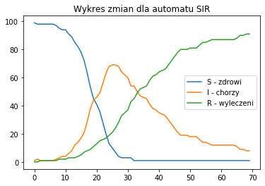

```python
s1 = [x[0] for x in stats]
i1 = [x[1] for x in stats]
r1 = [x[2] for x in stats]
plt.plot(s1)
plt.plot(i1)
plt.plot(r1)
plt.title('Wykres zmian dla automatu SIR')
plt.legend(['S - zdrowi', 'I - chorzy', 'R - wyleczeni'])
```

Jak można zauważyć na wykresie, nawet dla tak niewielkiego automatu o 100 komórkach, kształt wykresu jest bardzo zbliżony do matematycznych funkcji opisujących przebieg epidemii. Z uwagi na bardzo długi czas generowania animacji, ograniczyłem się tutaj do 70 jednostek czasu.

Przeprowadziłem ponownie analizę - tym razem dla współczynnika przemieszczania się $\alpha$ na poziomie $0.1$:

```
0 1 2 3 4 5 6 7 8 9 10 11 12 13 14 15 16 17 18 19 20 21 22 23 24 25 26 27 28 29 30 31 32 33 34 35 36 37 38 39 40 41 42 43 44 45 46 47 48 49 50 51 52 53 54 55 56 57 58 59 60 61 62 63 64 65 66 67 68 69
```

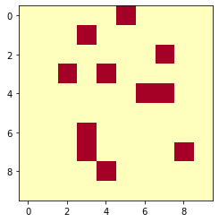

```python
x_max=10
y_max=10

c = 1.0/21
alpha = 0.1
beta = 0.5
start_i=1


population = x_max*y_max
movements = int(population*alpha)

SUSCEPTIBLE = 2
INFECTED = 0
REMOVED = 1

def animate_heat_map2():
    fig = plt.figure()
    anim = animation.FuncAnimation(fig, animate, init_func=init, frames=70, interval=20)
    anim.save('sir_2.gif', writer='imagemagick', fps=10)


animate_heat_map2()
```

```python
Image(url='https://raw.githubusercontent.com/Jck-eN/AGH_4_MOWNiT/master/lab7/gifs/sir_2_.gif')
```

[figure not shown]

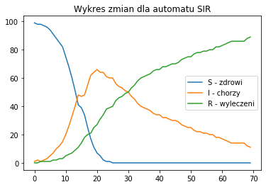

```python
s2 = [x[0] for x in stats]
i2 = [x[1] for x in stats]
r2 = [x[2] for x in stats]
plt.plot(s2)
plt.plot(i2)
plt.plot(r2)
plt.title('Wykres zmian dla automatu SIR')
plt.legend(['S - zdrowi', 'I - chorzy', 'R - wyleczeni'])
```

Zwiększenie współczynnika przemieszczania się - nawet na tak niewielkiej symulacji - spowodowało znaczne przyspieszenie wzrostu zakażeń. Maksimum zakażeń zostało osiągnięte nie w turze 25 jak poprzednio, lecz szybciej - w turze przed 20 turą.

### Test dla automatu 100x100

Wykonałem jeszcze jedną symulację - tym razem dla automatu 100x100 ze współczynnikiem przemieszczania $\alpha = 0.5\%$ i współczynnikiem zakażania $\beta = 0.3$

```
0 1 2 3 4 5 6 7 8 9 10 11 12 13 14 15 16 17 18 19 20 21 22 23 24 25 26 27 28 29 30 31 32 33 34 35 36 37 38 39 40 41 42 43 44 45 46 47 48 49 50 51 52 53 54 55 56 57 58 59 60 61 62 63 64 65 66 67 68 69 70 71 72 73 74 75 76 77 78 79 80 81 82 83 84 85 86 87 88 89 90 91 92 93 94 95 96 97 98 99 100 101 10…
```

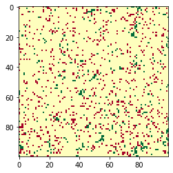

```python
x_max=100
y_max=100

c = 1.0/21
alpha = 0.005
beta = 0.3
start_i=1


stats = []
population = x_max*y_max
movements = int(population*alpha)

SUSCEPTIBLE = 2
INFECTED = 0
REMOVED = 1

def animate_heat_map3():
    fig = plt.figure()
    anim = animation.FuncAnimation(fig, animate, init_func=init, frames=150, interval=20)
    anim.save('sir_3.gif', writer='imagemagick', fps=10)


animate_heat_map3()
```

```python
Image(url='https://raw.githubusercontent.com/Jck-eN/AGH_4_MOWNiT/master/lab7/gifs/sir_3.gif')
```

[figure not shown]

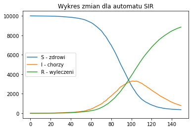

```python
s3 = [x[0] for x in stats]
i3 = [x[1] for x in stats]
r3 = [x[2] for x in stats]
plt.plot(s3)
plt.plot(i3)
plt.plot(r3)
plt.title('Wykres zmian dla automatu SIR')
plt.legend(['S - zdrowi', 'I - chorzy', 'R - wyleczeni'])
```

Przy rozmiarze populacji równym 10000, wykresy zakażeń są niemal idealnie ciągłe i zgodne (kształtem) z matematycznymi wyliczeniami

### Test dla zwiększonego przemieszczania się

Powtórzyłem symulację dla 10-krotnie zwiększonego współczynnika przemieszczania się $\alpha = 5\%$:

```
0 1 2 3 4 5 6 7 8 9 10 11 12 13 14 15 16 17 18 19 20 21 22 23 24 25 26 27 28 29 30 31 32 33 34 35 36 37 38 39 40 41 42 43 44 45 46 47 48 49 50 51 52 53 54 55 56 57 58 59 60 61 62 63 64 65 66 67 68 69 70 71 72 73 74 75 76 77 78 79 80 81 82 83 84 85 86 87 88 89 90 91 92 93 94 95 96 97 98 99 100 101 10…
```

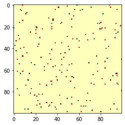

```python
x_max=100
y_max=100

c = 1.0/21
alpha = 0.05
beta = 0.3
start_i=1


stats = []
population = x_max*y_max
movements = int(population*alpha)

SUSCEPTIBLE = 2
INFECTED = 0
REMOVED = 1

def animate_heat_map4():
    fig = plt.figure()
    anim = animation.FuncAnimation(fig, animate, init_func=init, frames=150, interval=20)
    anim.save('sir_4.gif', writer='imagemagick', fps=10)


animate_heat_map4()
```

```python
Image(url='https://raw.githubusercontent.com/Jck-eN/AGH_4_MOWNiT/master/lab7/gifs/sir_4.gif')
```

[figure not shown]

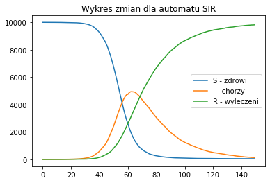

```python
s4 = [x[0] for x in stats]
i4 = [x[1] for x in stats]
r4 = [x[2] for x in stats]
plt.plot(s4)
plt.plot(i4)
plt.plot(r4)
plt.title('Wykres zmian dla automatu SIR')
plt.legend(['S - zdrowi', 'I - chorzy', 'R - wyleczeni'])
```

```python
print("a=0.5%: ", max(i3))
print("a=5%: ", max(i4))
print("Przyrost: ", max(i4)/max(i3)-1)
```

```
a=0.5%:  3308
a=5%:  4941
Przyrost:  0.493651753325272
```

### Wniosek:

Zwiększenie przemieszczania się populacji spowodowało przesunięcie krzywej zakażonych (przesunięcie maksimum ze 101 tury na 62) oraz przyrost maksymalnej liczby jednocześnie zakażonych o **49%**!

Symulacje epidemii nie kłamią - *#ZostańWDomu*